# Baby Project: Exploring the Social Media vs Productivity Dataset

## What kind of data analysis?

Look at the data, and in your markdown cells, explain what the data looks like.

- Create some summaries
- Create some graphs!
- Explain a few things. When I read this, I should understand something about this dataset.

## Part 1: Importing Libraries

I am using three libraries:

- pandas
- matplotlib.plyplot
- seaborn

```python
#Import pandas, matppotlib, and seaborn libraries
import pandas as pd
import matplotlib.pyplot as plt
import seaborn as sns


#Display plots directly below the code cell
%matplotlib inline
```

### Part 2: Loading and Exploring the Dataset

```python
# Load the dataset
df = pd.read_csv('social_media_vs_productivity.csv')

# View the first 30 rows
df.head(30)
```

|  | age | gender | job_type | daily_social_media_time | social_platform_preference | number_of_notifications | work_hours_per_day | perceived_productivity_score | actual_productivity_score | stress_level | sleep_hours | screen_time_before_sleep | breaks_during_work | uses_focus_apps | has_digital_wellbeing_enabled | coffee_consumption_per_day | days_feeling_burnout_per_month | weekly_offline_hours | job_satisfaction_score |
| --- | --- | --- | --- | --- | --- | --- | --- | --- | --- | --- | --- | --- | --- | --- | --- | --- | --- | --- | --- |
| 0 | 56 | Male | Unemployed | 4.180940 | Facebook | 61 | 6.753558 | 8.040464 | 7.291555 | 4.0 | 5.116546 | 0.419102 | 8 | False | False | 4 | 11 | 21.927072 | 6.336688 |
| 1 | 46 | Male | Health | 3.249603 | Twitter | 59 | 9.169296 | 5.063368 | 5.165093 | 7.0 | 5.103897 | 0.671519 | 7 | True | True | 2 | 25 | 0.000000 | 3.412427 |
| 2 | 32 | Male | Finance | NaN | Twitter | 57 | 7.910952 | 3.861762 | 3.474053 | 4.0 | 8.583222 | 0.624378 | 0 | True | False | 3 | 17 | 10.322044 | 2.474944 |
| 3 | 60 | Female | Unemployed | NaN | Facebook | 59 | 6.355027 | 2.916331 | 1.774869 | 6.0 | 6.052984 | 1.204540 | 1 | False | False | 0 | 4 | 23.876616 | 1.733670 |
| 4 | 25 | Male | IT | NaN | Telegram | 66 | 6.214096 | 8.868753 | NaN | 7.0 | 5.405706 | 1.876254 | 1 | False | True | 1 | 30 | 10.653519 | 9.693060 |
| 5 | 38 | Male | Finance | 1.512568 | Twitter | 50 | 6.429312 | NaN | 4.081026 | 5.0 | 5.515251 | 1.518612 | 5 | False | True | 5 | 2 | 0.000000 | 4.568728 |
| 6 | 56 | Female | Unemployed | 4.381070 | TikTok | 60 | 3.902309 | 6.420989 | 5.976408 | 7.0 | 7.549849 | 2.252624 | 4 | False | False | 4 | 20 | 24.084905 | 5.501373 |
| 7 | 36 | Female | Education | 4.089168 | Twitter | 49 | 6.560467 | 2.681830 | 2.446927 | 4.0 | 6.325507 | 0.747998 | 2 | False | False | 4 | 29 | 8.419648 | 3.444376 |
| 8 | 40 | Female | Education | 4.097401 | Instagram | 57 | 5.839590 | 3.219022 | 3.004240 | 4.0 | NaN | 0.000000 | 10 | False | True | 2 | 10 | 0.000000 | 1.960131 |
| 9 | 28 | Other | IT | 7.595577 | Twitter | 64 | 5.888936 | NaN | NaN | 3.0 | 6.761952 | 1.449841 | 10 | False | False | 1 | 18 | 6.959377 | 6.808102 |
| 10 | 28 | Male | IT | 3.341559 | Twitter | 57 | 11.022035 | 8.940636 | 7.983252 | 4.0 | 3.952547 | 1.028640 | 5 | True | True | 1 | 3 | 13.514515 | 9.414637 |
| 11 | 41 | Female | Finance | 2.200061 | Twitter | 59 | 10.147732 | 7.696546 | NaN | 9.0 | 6.091283 | 0.889256 | 8 | True | False | 4 | 30 | 8.732449 | 6.028926 |
| 12 | 53 | Male | Student | 2.715760 | TikTok | 77 | 5.637154 | 8.575504 | 7.715133 | NaN | 4.559258 | 0.599293 | 5 | False | False | 0 | 15 | 4.956755 | 8.770683 |
| 13 | 57 | Male | Education | 0.000000 | Twitter | 60 | 6.822442 | 8.850758 | 7.930675 | 5.0 | 6.764830 | 1.341070 | 3 | False | False | 4 | 27 | 18.052656 | 7.563358 |
| 14 | 41 | Male | Education | 3.773326 | TikTok | 65 | 8.636782 | 7.511934 | 6.773923 | 10.0 | 7.921161 | 1.263446 | 6 | True | False | 4 | 20 | 12.767974 | 6.849160 |
| 15 | 20 | Male | Student | 5.826311 | TikTok | 67 | 4.718497 | 2.645825 | 2.861171 | 5.0 | 8.301198 | 1.087081 | 9 | False | False | 4 | 0 | 8.095881 | 2.179692 |
| 16 | 39 | Male | Finance | 2.305803 | Twitter | 64 | 7.050821 | 6.983516 | 6.629587 | 9.0 | 4.847608 | 0.070189 | 2 | False | False | 3 | 9 | 12.110620 | NaN |
| 17 | 19 | Male | Health | 5.621220 | Twitter | 52 | 8.201916 | 2.154417 | 2.062080 | 1.0 | 5.223211 | 1.957239 | 3 | False | False | 2 | 6 | 20.032649 | 1.731725 |
| 18 | 41 | Female | Health | NaN | Twitter | 47 | 8.618984 | 8.515498 | 7.428871 | 5.0 | 6.275959 | 0.000000 | 2 | False | False | 2 | 26 | 0.229511 | 5.590406 |
| 19 | 61 | Female | Education | 1.445358 | Twitter | 62 | 6.419898 | 6.873341 | 5.957137 | 6.0 | 6.975413 | 0.000000 | 4 | True | True | 3 | 17 | 14.088959 | 5.442305 |
| 20 | 47 | Other | Health | 1.437666 | TikTok | 63 | 7.610461 | 7.832933 | 6.969125 | 7.0 | 5.399601 | 1.035228 | 10 | False | False | 2 | 22 | 3.565713 | 6.490481 |
| 21 | 55 | Female | Finance | 0.071503 | TikTok | 50 | 7.093237 | 8.968751 | 8.119665 | 5.0 | 5.223283 | 0.880365 | 2 | False | False | 1 | 21 | 4.720501 | 8.548482 |
| 22 | 19 | Male | Health | 5.916044 | Twitter | 65 | 6.592757 | 3.873519 | 2.974137 | 5.0 | 5.546582 | 0.829939 | 1 | False | False | 2 | 22 | 10.619489 | 3.207401 |
| 23 | 38 | Male | IT | 4.030315 | TikTok | 57 | 6.299842 | 6.851403 | 6.073044 | 7.0 | 5.006478 | 1.260447 | 6 | True | False | 1 | 13 | 14.251701 | 5.784979 |
| 24 | 50 | Male | Finance | 4.242185 | Instagram | 58 | 5.068889 | 2.428811 | 1.438418 | NaN | 7.707291 | 0.348540 | 7 | True | False | 2 | 14 | 14.331847 | 0.842077 |
| 25 | 29 | Male | Student | 1.551556 | Telegram | 52 | 7.965374 | 8.564363 | 7.209460 | 3.0 | 6.711047 | 0.772266 | 8 | False | False | 0 | 22 | 6.724090 | 7.587604 |
| 26 | 39 | Female | Education | 4.593419 | Facebook | 73 | 10.619575 | 3.230612 | 3.660009 | 2.0 | 6.773534 | 1.961318 | 5 | True | False | 0 | 15 | 16.921902 | 4.416550 |
| 27 | 61 | Female | Finance | 1.984596 | Telegram | 56 | 5.983900 | 5.981160 | 5.672383 | 3.0 | NaN | 0.687990 | 10 | True | False | 0 | 9 | 0.690294 | 5.181730 |
| 28 | 42 | Male | Health | 2.076693 | Telegram | 57 | 8.254002 | 5.140098 | 4.767332 | 3.0 | 3.000000 | 1.560576 | 0 | True | True | 2 | 0 | 16.438964 | 6.176500 |
| 29 | 44 | Male | Finance | 5.144763 | Facebook | 55 | 8.096872 | 2.218581 | 2.416909 | NaN | 5.009060 | 1.748973 | 0 | False | False | 0 | 24 | 5.104789 | 0.518372 |

```python
df.shape
```

```
(30000, 19)
```

```python
# Showing the Summary Stats
df.describe(include='all').round(2)
```

|  | age | gender | job_type | daily_social_media_time | social_platform_preference | number_of_notifications | work_hours_per_day | perceived_productivity_score | actual_productivity_score | stress_level | sleep_hours | screen_time_before_sleep | breaks_during_work | uses_focus_apps | has_digital_wellbeing_enabled | coffee_consumption_per_day | days_feeling_burnout_per_month | weekly_offline_hours | job_satisfaction_score |
| --- | --- | --- | --- | --- | --- | --- | --- | --- | --- | --- | --- | --- | --- | --- | --- | --- | --- | --- | --- |
| count | 30000.00 | 30000 | 30000 | 27235.00 | 30000 | 30000.00 | 30000.00 | 28386.00 | 27635.00 | 28096.00 | 27402.00 | 27789.00 | 30000.00 | 30000 | 30000 | 30000.00 | 30000.00 | 30000.00 | 27270.00 |
| unique | NaN | 3 | 6 | NaN | 5 | NaN | NaN | NaN | NaN | NaN | NaN | NaN | NaN | 2 | 2 | NaN | NaN | NaN | NaN |
| top | NaN | Male | Education | NaN | TikTok | NaN | NaN | NaN | NaN | NaN | NaN | NaN | NaN | False | False | NaN | NaN | NaN | NaN |
| freq | NaN | 14452 | 5055 | NaN | 6096 | NaN | NaN | NaN | NaN | NaN | NaN | NaN | NaN | 20979 | 22602 | NaN | NaN | NaN | NaN |
| mean | 41.49 | NaN | NaN | 3.11 | NaN | 59.96 | 6.99 | 5.51 | 4.95 | 5.51 | 6.50 | 1.03 | 4.99 | NaN | NaN | 2.00 | 15.56 | 10.36 | 4.96 |
| std | 13.84 | NaN | NaN | 2.07 | NaN | 7.72 | 2.00 | 2.02 | 1.88 | 2.87 | 1.46 | 0.65 | 3.17 | NaN | NaN | 1.41 | 9.25 | 7.28 | 2.12 |
| min | 18.00 | NaN | NaN | 0.00 | NaN | 30.00 | 0.00 | 2.00 | 0.30 | 1.00 | 3.00 | 0.00 | 0.00 | NaN | NaN | 0.00 | 0.00 | 0.00 | 0.00 |
| 25% | 30.00 | NaN | NaN | 1.64 | NaN | 55.00 | 5.64 | 3.76 | 3.37 | 3.00 | 5.49 | 0.53 | 2.00 | NaN | NaN | 1.00 | 8.00 | 4.54 | 3.36 |
| 50% | 41.00 | NaN | NaN | 3.03 | NaN | 60.00 | 6.99 | 5.53 | 4.95 | 6.00 | 6.50 | 1.01 | 5.00 | NaN | NaN | 2.00 | 16.00 | 10.01 | 4.95 |
| 75% | 53.00 | NaN | NaN | 4.37 | NaN | 65.00 | 8.35 | 7.27 | 6.53 | 8.00 | 7.50 | 1.48 | 8.00 | NaN | NaN | 3.00 | 24.00 | 15.30 | 6.58 |
| max | 65.00 | NaN | NaN | 17.97 | NaN | 90.00 | 12.00 | 9.00 | 9.85 | 10.00 | 10.00 | 3.00 | 10.00 | NaN | NaN | 10.00 | 31.00 | 40.96 | 10.00 |

```python
# Checking the number of null values
df.isnull().sum()
```

```
age                                  0
gender                               0
job_type                             0
daily_social_media_time           2765
social_platform_preference           0
number_of_notifications              0
work_hours_per_day                   0
perceived_productivity_score      1614
actual_productivity_score         2365
stress_level                      1904
sleep_hours                       2598
screen_time_before_sleep          2211
breaks_during_work                   0
uses_focus_apps                      0
has_digital_wellbeing_enabled        0
coffee_consumption_per_day           0
days_feeling_burnout_per_month       0
weekly_offline_hours                 0
job_satisfaction_score            2730
dtype: int64
```

### Dataset Observations:

This dataset contains 30,000 records and 19 columns.

This dataset has collected multiple records that cover the following topics:

- Demographics
- Social Media Usage
- Work Productivity
- Personal Health

## Part 3: Creating Summaries

We are going to explore the relationship between the job types, daily social media time, perceived productivity and actual productivity

```python
# Grouping by job type and comparing daily social media time, perceived productivity scores and actual productivity scores
df.groupby("job_type").agg({
    "daily_social_media_time": ['min', 'max', 'mean', 'std', 'count'],
    "perceived_productivity_score": ['min', 'max', 'mean', 'std', 'count'],
    "actual_productivity_score": ['min', 'max', 'mean', 'std', 'count']
}).round(2)
```

| job_type | daily_social_media_time min | daily_social_media_time max | daily_social_media_time mean | daily_social_media_time std | daily_social_media_time count | perceived_productivity_score min | perceived_productivity_score max | perceived_productivity_score mean | perceived_productivity_score std | perceived_productivity_score count | actual_productivity_score min | actual_productivity_score max | actual_productivity_score mean | actual_productivity_score std | actual_productivity_score count |
| --- | --- | --- | --- | --- | --- | --- | --- | --- | --- | --- | --- | --- | --- | --- | --- |
| Education | 0.0 | 17.75 | 3.10 | 2.04 | 4591 | 2.0 | 9.0 | 5.49 | 2.03 | 4779 | 0.52 | 9.66 | 4.93 | 1.89 | 4667 |
| Finance | 0.0 | 17.73 | 3.08 | 2.07 | 4546 | 2.0 | 9.0 | 5.51 | 2.04 | 4757 | 0.53 | 9.36 | 4.97 | 1.90 | 4639 |
| Health | 0.0 | 17.21 | 3.07 | 2.02 | 4480 | 2.0 | 9.0 | 5.48 | 2.04 | 4662 | 0.62 | 9.38 | 4.92 | 1.90 | 4540 |
| IT | 0.0 | 17.82 | 3.13 | 2.06 | 4542 | 2.0 | 9.0 | 5.56 | 2.02 | 4741 | 0.30 | 9.85 | 5.01 | 1.88 | 4618 |
| Student | 0.0 | 17.86 | 3.14 | 2.12 | 4572 | 2.0 | 9.0 | 5.48 | 2.02 | 4752 | 0.60 | 9.09 | 4.90 | 1.88 | 4616 |
| Unemployed | 0.0 | 17.97 | 3.16 | 2.14 | 4504 | 2.0 | 9.0 | 5.54 | 1.99 | 4695 | 0.30 | 9.15 | 4.99 | 1.85 | 4555 |

## Part 4: Visualization

We are going to visualize the relationship between the job types, daily social media time, perceived productivity and actual productivity

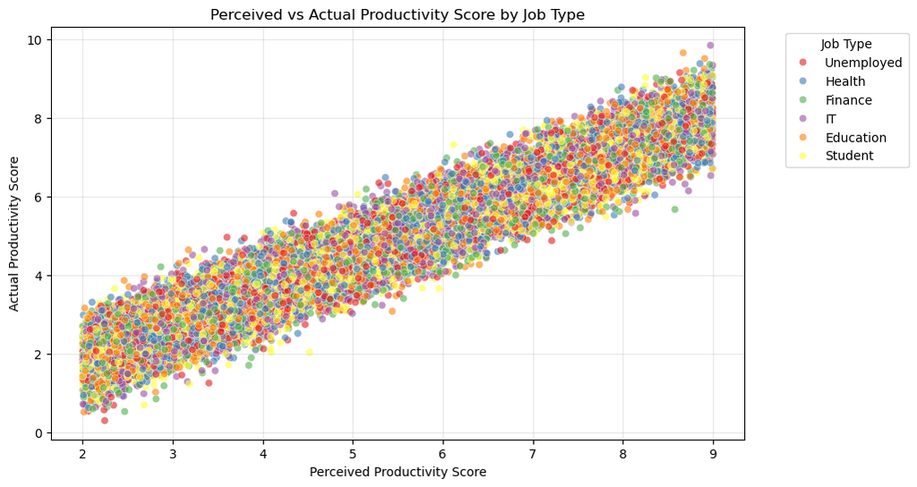

```python
## Perceived vs Actual Productivity Score by Job Type Scatterplot
plt.figure(figsize=(10, 6))
sns.scatterplot(x="perceived_productivity_score", y="actual_productivity_score",
                hue="job_type", data=df, palette="Set1", alpha=0.6)
plt.title("Perceived vs Actual Productivity Score by Job Type")
plt.xlabel("Perceived Productivity Score")
plt.ylabel("Actual Productivity Score")
plt.grid(True, alpha=0.3)
plt.legend(title="Job Type", bbox_to_anchor=(1.05, 1), loc='upper left')
plt.show()
```

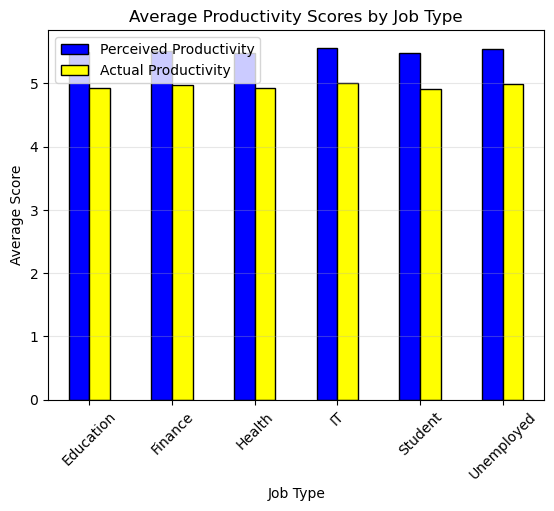

```python
## Average Productivity Scores By Job Type Bar chart
productivity_by_job = df.groupby("job_type")[["perceived_productivity_score",
                                                "actual_productivity_score"]].mean()

plt.figure(figsize=(10, 6))
productivity_by_job.plot(kind='bar', color=['blue', 'yellow'], edgecolor='black')
plt.title("Average Productivity Scores by Job Type")
plt.xlabel("Job Type")
plt.ylabel("Average Score")
plt.xticks(rotation=45)
plt.legend(["Perceived Productivity", "Actual Productivity"])
plt.grid(axis='y', alpha=0.3)
plt.show()
```

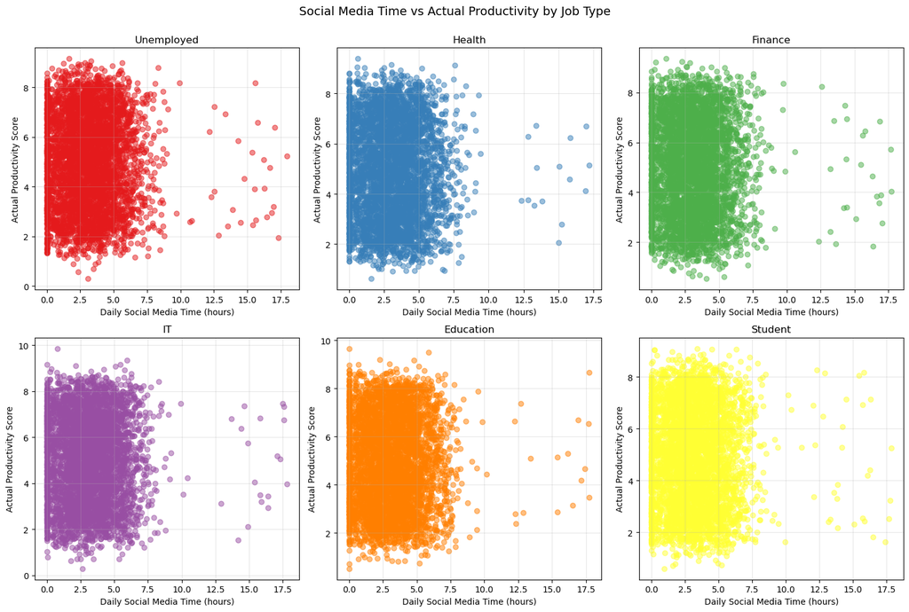

```python
## Social Media Time vs Actual Productivity by Job Type - Scatterplot for each
job_types = df['job_type'].unique()

fig, axes = plt.subplots(2, 3, figsize=(15, 10))
axes = axes.flatten()

for i, job in enumerate(job_types):
    job_data = df[df['job_type'] == job]
    axes[i].scatter(job_data['daily_social_media_time'],
                   job_data['actual_productivity_score'],
                   alpha=0.5, color=sns.color_palette('Set1', len(job_types))[i])
    axes[i].set_title(f'{job}')
    axes[i].set_xlabel('Daily Social Media Time (hours)')
    axes[i].set_ylabel('Actual Productivity Score')
    axes[i].grid(True, alpha=0.3)

plt.suptitle('Social Media Time vs Actual Productivity by Job Type', fontsize=14, y=1.00)
plt.tight_layout()
plt.show()
```

## Part 5: Analysis Insights

Based on the summaries and visualizations, here are my insights about the productivity patterns of the dataset:

- There seems to be a consistent relationship that an individuals' perceived productivity on average slightly over estimates their actual productivity
- This could mean that people estimate their own productivity relatively accurately
- The summaries reveal there is no conclusive relationship between Daily Social Media Time and Actual Productivity Score
- Although I am thoroughly impressed by the person who works in education, spent more than 17.5 hours in a day on social media and had an actual productivity score above 8 (this is an outlier and could be an entry error)